# Herencia

La herencia nos permite definir una clase que hereda todos los métodos y propiedades de otra clase.

**Clase padre** es la clase que se hereda, también llamada clase base o principal.

**Clase hijo** es la clase que hereda de otra clase, también llamada clase derivada.

## Clase padre

Cualquier clase puede ser una clase principal, por lo que la sintaxis es la misma que la de crear cualquier otra clase

```python
class Person:
  def __init__(self, fname, lname):
    self.firstname = fname
    self.lastname = lname

  def printname(self):
    print(self.firstname, self.lastname)


x = Person("John", "Doe")
x.printname()
```

```
John Doe
```

## Clase hijo

Para crear una clase que herede la funcionalidad de otra clase, envíe la clase principal como parámetro al crear la clase secundaria:

Ejemplo:

```python
class Student(Person):
  pass
  # Utilice la palabra 'pass' cuando no desee agregar ninguna otra propiedad o método a la clase.
```

Ahora la clase Student tiene las mismas propiedades y métodos que la clase Person.

**Ejemplo**

Utilice la clase Student para crear un objeto y luego ejecute el método printname:

```python
x = Student("Mike", "Olsen")
x.printname()
```

```
Mike Olsen
```

### Agregue la función **init**

Hasta ahora hemos creado una clase hija que hereda las propiedades y métodos de su clase padre. Queremos agregar la función **init**() a la clase secundaria (en lugar de la palabra clave pass).

Ejemplo

```python
class Student(Person):
  def __init__(self, fname, lname):
    # agrega algunas propiedades
    self.fname = fname
    self.lname = lname
```

## IMPORTANTE

Cuando agrega la función **init**(), la clase secundaria ya no heredará la función **init**() del padre.

*La función **init** del hijo anula la herencia de la funcion **init** del padre.*

Para mantener la herencia de la función **init**() del padre, agregue una llamada a la función **init**() del padre:

```python
class Student(Person):
  def __init__(self, fname, lname):
    Person.__init__(self, fname, lname)

x2 = Student('Jeffrey', 'Kaplan')
x2.printname()
```

```
Jeffrey Kaplan
```

## Utilice la función super()

Python también tiene una función `super()` que hará que la clase hija herede todos los métodos y propiedades de su clase padre:

```python
class Student(Person):
  def __init__(self, fname, lname):
    super().__init__(fname, lname)
```

Al utilizar la función super(), no es necesario utilizar el nombre del elemento principal, este heredará automáticamente los métodos y propiedades de su elemento principal.

## Agregar propiedades

Ejemplo Agregue una propiedad llamada año de graduación a la clase Estudiante:

```python
class Student(Person):
  def __init__(self, fname, lname, year):
    super().__init__(fname, lname)
    self.graduationyear = year
```

[output not shown]

Agregue un método llamado welcome a la clase Estudiante:

```python
class Student(Person):
  def __init__(self, fname, lname, year):
    super().__init__(fname, lname)
    self.graduationyear = year

  def welcome(self):
    print("Welcome", self.firstname, self.lastname, "to the class of", self.graduationyear)
```

```python
x3 = Student('Jeffrey', 'Kaplan', 2023)
x3.welcome()
```

```
Welcome Jeffrey Kaplan to the class of 2023
```

Si agrega un método en la clase secundaria con el mismo nombre que una función en la clase principal, se anulará la herencia del método principal.

# Ejemplo utilizando herencia en Python

## Paso 1: Definición de la clase Base

Vamos a crear una clase base llamada `Persona` que contendrá dos atributos: `nombre` y `edad`.

```python
class Persona:
    def __init__(self, nombre, edad):
        self.nombre = nombre
        self.edad = edad

    def mostrar_informacion(self):
        print(f"Nombre: {self.nombre}")
        print(f"Edad: {self.edad}")
```

## Paso 2: Creación de una clase Derivada (hija)

vamos a crear una clase derivada llamada `Empleado` que heredará los atributos y métodos de la clase `Persona`. Además, añadiremos un nuevo atributo: `salario`.

```python
class Empleado(Persona):
    def __init__(self, nombre, edad, salario):
        super().__init__(nombre, edad)
        self.salario = salario

    def mostrar_informacion(self):
        super().mostrar_informacion()
        print(f"Salario: {self.salario}")
```

En este código, hemos utilizado `super()` para llamar al método `__init__`de la clase base y hemos sobreescrito el método `mostrar_informacion` para incluir información adicional sobre el salario.

## Paso 3: Creación de Instancias y Prueba de los Métodos

Ahora crearemos instancias de las clases `Persona` y `Empleado`, y luego llamaremos al método `mostrar_informacion` para cada una de ellas.

```python
# Creando una instancia de la clase Persona
persona1 = Persona("Alice", 30)
persona1.mostrar_informacion()

# Creando una instancia de la clase Empleado
empleado1 = Empleado("Bob", 40, 50000)
empleado1.mostrar_informacion()
```

```
Nombre: Alice
Edad: 30
Nombre: Bob
Edad: 40
Salario: 50000
```

## ACTIVIDAD EN CLASES

### Investigue y desarrolle el ejemplo anterior en los lenguajes C++ y Java.

# Polimorfismo de Python

La palabra "polimorfismo" significa "muchas formas" y en programación se refiere a métodos/funciones/operadores con el mismo nombre que se pueden ejecutar en muchos objetos o clases.

## Polimorfismo de función

Un ejemplo de una función de Python que se puede utilizar en diferentes objetos es la función len().

Ejemplos

1. String

```python
x = "Hello World!"

print(len(x))
```

```
12
```

2. Tuplas

```python
mytuple = ("apple", "banana", "cherry")

print(len(mytuple))
```

```
3
```

3. Diccionarios

```python
thisdict = {
  "brand": "Ford",
  "model": "Mustang",
  "year": 1964
}

print(len(thisdict))
```

```
3
```

## Polimorfismo de clase

El polimorfismo se usa a menudo en métodos de clase, donde podemos tener varias clases con el mismo nombre de método.

Por ejemplo, digamos que tenemos tres clases: Car, Boat y Plane, y todas tienen un método llamado move():

```python
class Car:
  def __init__(self, brand, model):
    self.brand = brand
    self.model = model

  def move(self):
    print("Drive!")

class Boat:
  def __init__(self, brand, model):
    self.brand = brand
    self.model = model

  def move(self):
    print("Sail!")

class Plane:
  def __init__(self, brand, model):
    self.brand = brand
    self.model = model

  def move(self):
    print("Fly!")

car1 = Car("Ford", "Mustang")       #Create a Car class
boat1 = Boat("Ibiza", "Touring 20") #Create a Boat class
plane1 = Plane("Boeing", "747")     #Create a Plane class

for x in (car1, boat1, plane1):
    x.move()
```

```
Drive!
Sail!
Fly!
```

Debido al polimorfismo podemos ejecutar el mismo método para las tres clases.

¿Qué pasa con las clases con clases secundarias con el mismo nombre? ¿Podemos usar polimorfismo allí?

**Sí**. Si usamos el ejemplo anterior y creamos una clase principal llamada Vehículo, y creamos clases secundarias de Vehículo, Coche, Barco y Avión, las clases secundarias heredan los métodos del Vehículo, pero pueden anularlos:

```python
class Vehicle:
  def __init__(self, brand, model):
    self.brand = brand
    self.model = model

  def move(self):
    print("Move!")

class Car(Vehicle):
  pass

class Boat(Vehicle):
  def move(self):
    print("Sail!")

class Plane(Vehicle):
  def move(self):
    print("Fly!")

car1 = Car("Ford", "Mustang") #Create a Car object
boat1 = Boat("Ibiza", "Touring 20") #Create a Boat object
plane1 = Plane("Boeing", "747") #Create a Plane object

for x in (car1, boat1, plane1):
  print(x.brand)
  print(x.model)
  x.move()
```

```
Ford
Mustang
Move!
Ibiza
Touring 20
Sail!
Boeing
747
Fly!
```

# **Ejemplo**

Crea una clase Vehiculo con atributos `color` y `numero_de_ruedas`. Luego, crea clases hijo como Coche, Moto y Bicicleta, que hereden de `Vehiculo`. Cada una de estas clases hijo debe tener atributos adicionales únicos.

```python
# Clase Padre
class Vehiculo:
    def __init__(self, color, numero_de_ruedas):
        self.color = color
        self.numero_de_ruedas = numero_de_ruedas

    def describir(self):
        print(f"Soy un vehículo de color {self.color} y tengo {self.numero_de_ruedas} ruedas.")

# Clase Hija: Coche
class Coche(Vehiculo):
    def __init__(self, color, numero_de_ruedas, velocidad_maxima):
        super().__init__(color, numero_de_ruedas)
        self.velocidad_maxima = velocidad_maxima

    def describir(self):
        print(f"Soy un coche de color {self.color} con una velocidad máxima de {self.velocidad_maxima} km/h.")

# Clase Hija: Moto
class Moto(Vehiculo):
    def __init__(self, color, numero_de_ruedas, tipo):
        super().__init__(color, numero_de_ruedas)
        self.tipo = tipo  # Deportiva, Turismo, etc.

    def describir(self):
        print(f"Soy una moto {self.tipo} de color {self.color}.")

# Clase Hija: Bicicleta
class Bicicleta(Vehiculo):
    def __init__(self, color, numero_de_ruedas, tipo):
        super().__init__(color, numero_de_ruedas)
        self.tipo = tipo  # Montaña, Carretera, etc.

    def describir(self):
        print(f"Soy una bicicleta {self.tipo} de color {self.color}.")
```

```python
# Creando instancias y describiendo cada una
coche = Coche("rojo", 4, 200)
coche.describir()

moto = Moto("azul", 2, "deportiva")
moto.describir()

bicicleta = Bicicleta("verde", 2, "de montaña")
bicicleta.describir()
```

```
Soy un coche de color rojo con una velocidad máxima de 200 km/h.
Soy una moto deportiva de color azul.
Soy una bicicleta de montaña de color verde.
```

## ACTIVIDAD EN CLASES

### Investigue y desarrolle el ejemplo anterior en los lenguajes C++ y Java.

# **Diagrama de clases**

Un diagrama de clases en Lenguaje Unificado de Modelado (UML) es un tipo de digrama de estructura estática que describe la estructura de un sistema mostrando las clases del sistema, sus atributos, métodos y las relaciones entre los objetos.

## **Visibilidad**

Para especificar la visibilidad de un miembro de la clase (es decir, cualquier atributo o método), se coloca uno de los siguientes signos delante de ese miembro:

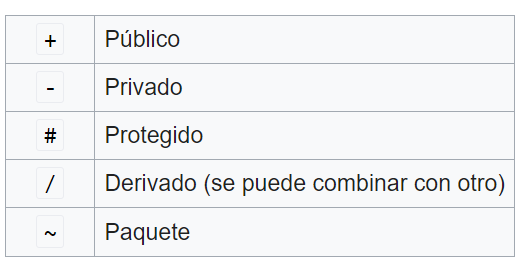

## **Relaciones**

Una relación es un término general que abarca los tipos específicos de conexiones lógicas que se pueden encontrar en los diagramas de clases y objetos. UML presenta las siguientes relaciones:

- `Asociación` representa a una familia de enlaces. Una asociación binaria (entre dos clases) normalmente se representa con una línea continua. Una misma asociación puede relacionar cualquier número de clases. Una asociación que relacione tres clases se llama asociación ternaria. A una asociación se le puede asignar un nombre, y en sus extremos se puede hacer indicaciones, como el rol que desempeña la asociación, los nombres de las clases relacionadas, su multiplicidad, su visibilidad, y otras propiedades. Hay cuatro tipos diferentes de asociación: bidireccional, unidireccional, agregación (en la que se incluye la composición) y reflexiva. Las asociaciones unidireccional y bidireccional son las más comunes. Por ejemplo, una clase vuelo se asocia con una clase avión de forma bidireccional. La asociación representa la relación estática que comparten los objetos de ambas clases.

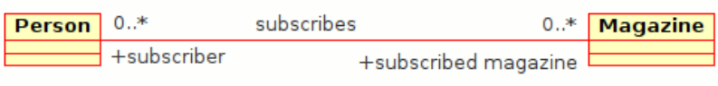

- `Agregación` o agrupación es una variante de la relación de asociación “tiene un”: la agregación es más específica que la asociación. Se trata de una asociación que representa una relación de tipo parte-todo o parte-de.

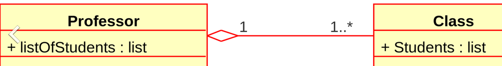

Como se puede ver en la imagen del ejemplo (en inglés), un Profesor 'tiene una' clase a la que enseña.

Al ser un tipo de asociación, una agregación puede tener un nombre y las mismas indicaciones en los extremos de la línea. Sin embargo, una agregación no puede incluir más de dos clases; debe ser una asociación binaria.

Una agregación se puede dar cuando una clase es una colección o un contenedor de otras clases, pero a su vez, el tiempo de vida de las clases contenidas no tienen una dependencia fuerte del tiempo de vida de la clase contenedora (de el todo). Es decir, el contenido de la clase contenedora no se destruye automáticamente cuando desaparece dicha clase.

- `Composición` La representación en UML de una relación de composición es mostrada con una figura de diamante relleno del lado de la clase contenedora, es decir al final de la línea que conecta la clase contenido con la clase contenedor.

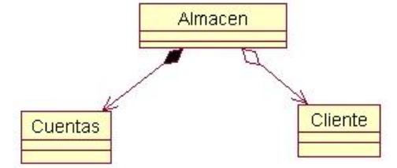

**Diferencias entre Composición y Agregación**

- Relación de Composición
1. Cuando intentamos representar un todo y sus partes. Ejemplo, un motor es una parte de un coche.
2. Cuando se elimina el contenedor, el contenido también es eliminado. Ejemplo, si eliminamos una universidad eliminamos igualmente sus departamentos.

**Relación de Agregación (o Agrupación)**

1. Cuando representamos las relaciones en un software o base de datos. Ejemplo, el modelo de motor MTR01 es parte del coche MC01. Como tal, el motor MTR01 puede ser parte de cualquier otro modelo de coche, es decir si eliminamos el coche MC01 no es necesario eliminar el motor pues podemos usarlo en otro modelo.
2. Cuando el contenedor es eliminado, el contenido usualmente no es destruido. Ejemplo, un profesor tiene estudiantes, cuando el profesor muere los estudiantes no mueren con él o ella.
- `Herencia` Este tipo de relaciones permiten que una clase reciba los atributos y métodos de otra clase (padre o super clase). Estos atributos y métodos recibidos se suman a los que la clase tiene por sí misma.

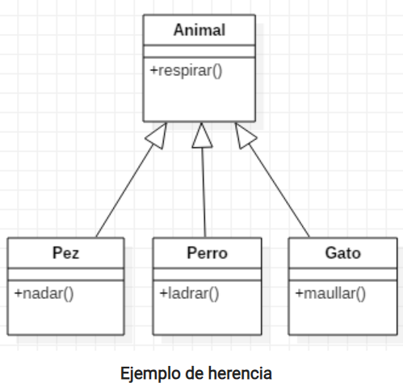

# Ejercicios

Desarrolle los ejercicios en los lenguajes de programación Python, C++ y Java.

1. Sistema de Gestión de Productos
- Crear una clase base `Producto` que contenga atributos como `nombre`, `precio` y `categoría`.
- Crear clases derivadas para diferentes tipos de productos como `Electrónico`, `Alimenticio` y `Vestimenta`. Añadir atributos únicos para cada clase derivada.
- Implementar un método llamado `mostrar_detalle` en cada clase para mostrar los detalles del producto de una manera única para cada tipo de producto.
2. Sistema de Empleados de una Empresa
- Crear una clase base `Empleado` que contenga atributos como `nombre`, `edad` y `salario`.
- Crear clases derivadas como `Gerente`, `Ingeniero` y `Asistente` con atributos y métodos únicos para cada rol.
- Implementar un método `describir_rol` en cada clase para describir el rol de un empleado de una manera que sea específica para su posición.
3. Sistema de Animales
- Crear una clase base `Animal` con atributos como `nombre` y `edad`, y un método `sonido` que deberá ser implementado por las clases derivadas.
- Crear clases derivadas para diferentes tipos de animales, como `Perro`, `Gato` y `Pájaro`, cada una con una implementación única del método `sonido`.
4. Sistema de Reservas de Vuelos
- Crear una clase base `Reserva` que contenga atributos como `nombre_del_pasajero`, `número_de_vuelo` y `fecha`.
- Crear clases derivadas como `ReservaEconómica`, `ReservaBusiness` y `ReservaPrimeraClase` que hereden de Reserva y que contengan atributos y métodos únicos para cada tipo de reserva.
- Implementar un método `mostrar_detalle` en cada clase para mostrar los detalles de la reserva de una forma única dependiendo del tipo de clase de reserva.

## **Desafío**

### Sistema de Gestión Universitaria

Desarrolle un sistema para gestionar una universidad que tenga las siguientes características:

1. Clase Persona:
- Atributos: nombre, apellido, fecha_de_nacimiento.
- Métodos: presentarse, que deberá imprimir una presentación genérica de una persona.
2. Clase Estudiante (hereda de Persona):
- Atributos: matrícula, carrera, semestre.
- Métodos:
  - estudiar: recibirá una materia y horas de estudio y imprimirá un mensaje indicando que el estudiante ha estudiado dicha materia durante X horas.
  - presentarse: deberá sobrescribir el método de la clase Persona para incluir información del estudiante.
3. Clase Profesor (hereda de Persona):
- Atributos: número_empleado, departamento.
- Métodos:
  - enseñar: recibirá una materia y imprimirá un mensaje indicando que el profesor está enseñando dicha materia.
  - presentarse: deberá sobrescribir el método de la clase Persona para incluir información del profesor.
4. Clase Asignatura:
- Atributos: nombre, código, créditos.
- Métodos: mostrar_información: imprimirá la información de la asignatura.
5. Clase Grupo:
- Atributos: número_grupo, asignatura (un objeto de tipo Asignatura), profesor (un objeto de tipo Profesor), estudiantes (una lista de objetos de tipo Estudiante).
- Métodos:
  - agregar_estudiante: permitirá agregar un estudiante al grupo.
  - eliminar_estudiante: permitirá eliminar un estudiante del grupo.
  - mostrar_grupo: mostrará la información del grupo incluyendo el profesor asignado y la lista de estudiantes.
6. Clase ProgramaAcademico:
- Atributos: nombre, codigo, grupos (una lista de objetos de tipo Grupo).
- Métodos:
  - agregar_grupo: permitirá agregar un grupo al programa académico.
  - eliminar_grupo: permitirá eliminar un grupo del programa académico.
  - mostrar_programa: mostrará la información del programa académico incluyendo todos los grupos con su respectiva información.

Desarrolle un script que cree varias instancias de estas clases y demuestre la interacción entre ellas a través de los diferentes métodos implementados.

**Consideraciones adicionales:**

- Implemente validaciones necesarias para evitar inconsistencias (como eliminar un estudiante que no existe en un grupo).
- Implemente una interfaz textual que permita a un usuario interactuar con el sistema (crear objetos, asignar estudiantes a grupos, etc.).
- Incluya comentarios y docstrings que expliquen su código adecuadamente.